# swirl Lesson 4: Count Outcomes

Get the 95% confidence interval for exp(b1) by exponentiating confint(mdl, ‘date’)

```r
exp(confint(mdl, 'date'))
```

```
   2.5 %   97.5 %
1.002192 1.002399
```

Visits are estimated to increase by a factor of between 1.002192 and 1.002399 per day. That is, between 0.2192% and 0.2399% per day. This actually represents more than a doubling every year.

Our model looks like a pretty good description of the data, but no model is perfect and we can often learn about a data generation process by looking for a model’s shortcomings. As shown in the figure, one thing about our model is ‘zero inflation’ in the first two weeks of January 2011, before the site had any visits. The model systematically overestimates the number of visits during this time. A less obvious thing is that the standard deviation of the data may be increasing with lambda faster than a Poisson model allows. This possibility can be seen in the rightmost plot by visually comparing the spread of green dots with the standard deviation predicted by the model (black dashes.) Also, there are four or five bursts of popularity during which the number of visits far exceeds two standard deviations over average. Perhaps these are due to mentions on another site.

```r
idx <- 1:60
par(mfrow=c(1, 2))
plot(visits ~ date, hits[idx,],
     main='"Zero Inflation" 2011',
     xlab="Date", ylab="Visits", pch=21, bg='green')
lines(hits$date[idx], mdl$fitted.values[idx], lwd=5, col="black")
```

```r
points(as.Date("2011-01-10"), 5, cex=12, lwd=5)
text(as.Date("2011-01-5"), 9, "Zero Inflation", pos=4)
```

```r
plot(hits$date, hits$visits-mdl$fitted.values, pch=21, bg='green', main="Variance != Mean?", xlab="Date", ylab="Visits over Average")
lines(hits$date, sqrt(mdl$fitted.values), lwd=5, lty=2, col='black')
```

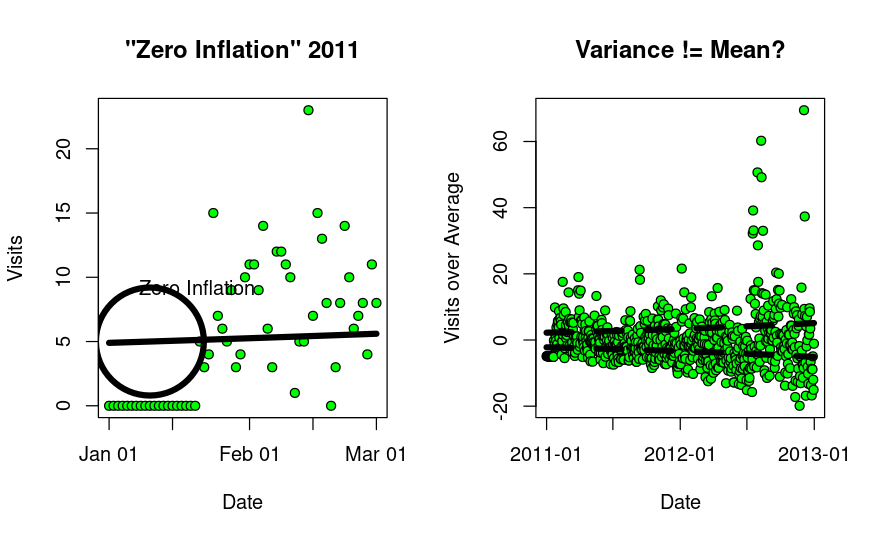

```r
lines(hits$date, -sqrt(mdl$fitted.values), lwd=5, lty=2, col='black')
rm(idx)
par(mfrow=c(1, 1))
```

It seems that at least some of them are. The simplystats column of our data records the number of visits to the Leek Group site which come from the related site, Simply Statistics. (I.e., visits due to clicks on a link to the Leek Group which appeared in a Simply Statisics post.)

```r
plot(visits ~ date, hits, pch=21, bg='lightgreen', main="Bursts of Popularity", xlab="Date", ylab="Visits")
points(simplystats ~ date, hits, pch=21, bg='black')
```

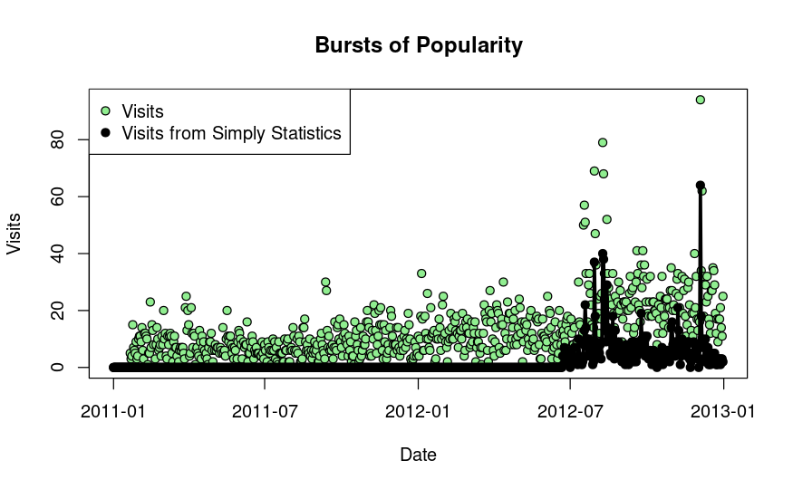

```r
lines(simplystats ~ date, hits, lwd=3)
legend('topleft', c("Visits", "Visits from Simply Statistics"), pch=21, pt.bg=c("lightgreen", "black"), bg="white")
```

In the figure, the maximum number of visits occurred in late 2012. Visits from the Simply Statistics blog were also at their maximum that day. To find the exact date we can use which.max(hits[,‘visits’]). Do this now.

```r
which.max(hits[,'visits'])
```

```
[1] 704
```

The maximum number of visits is recorded in row 704 of our data frame. Print that row by typing hits[704,].

```r
hits[704,]
```

|  | date | visits | simplystats |
| --- | --- | --- | --- |
| 704 | 2012-12-04 | 94 | 64 |

The maximum number of visits, 94, occurred on December 4, 2012, of which 64 came from the Simply Statistics blog. We might consider the 64 visits to be a special event, over and above normal. Can the difference, 94-64=30 visits, be attributed to normal traffic as estimated by our model? To check, we will need the value of lambda on December 4, 2012. This will be entry 704 of the fitted.values element of our model. Extract mdl$fitted.values[704] and store it in a variable named lambda.

```r
lambda <- mdl$fitted.values[704]
```

The number of visits explained by our model on December 4, 2012 are those of a Poisson random variable with mean lambda. We can find the 95th percentile of this distribution using qpois(.95, lambda). Try this now.

```r
qpois(.95, lambda)
```

```
[1] 33
```

So, 95% of the time we would see 33 or fewer visits, hence 30 visits would not be rare according to our model. It would seem that on December 4, 2012, the very high number of visits was due to references from Simply Statistics. To gauge the importance of references from Simply Statistics we may wish to model the proportion of traffic such references represent. Doing so will also illustrate the use of glm’s parameter, offset, to model frequencies and proportions.

A Poisson process generates counts, and counts are whole numbers, 0, 1, 2, 3, etc. A proportion is a fraction. So how can a Poisson process model a proportion? The trick is to include the denominator of the fraction, or more precisely its log, as an offset. Recall that in our data set, ‘simplystats’ is the visits from Simply Statistics, and ‘visits’ is the total number of visits. We would like to model the fraction simplystats/visits, but to avoid division by zero we’ll actually use simplystats/(visits+1). A Poisson model assumes that log(lambda) is a linear combination of predictors. Suppose we assume that log(lambda) = log(visits+1) + b0 + b1*date. In other words, if we insist that the coefficient of log(visits+1) be equal to 1, we are predicting the log of mean visits from Simply Statistics as a proportion of total visits: log(lambda/(visits+1)) = b0 + b1*date.

glm’s parameter, offset, has precisely this effect. It fixes the coefficient of the offset to 1. To create a model for the proportion of visits from Simply Statistics, we let offset=log(visits+1). Create such a Poisson model now and store it as a variable called mdl2.

```r
mdl2 <- glm(simplystats ~ date, poisson, hits, offset=log(visits+1))
```

Although summary(mdl2) will show that the estimated coefficients are significantly different than zero, the model is actually not impressive. We can illustrate why by looking at December 4, 2012, once again. On that day there were 64 actual visits from Simply Statistics. However, according to mdl2, 64 visits would be extremely unlikely. You can verify this weakness in the model by finding mdl2’s 95th percentile for that day. Recalling that December 4, 2012 was sample 704, find qpois(.95, mdl2$fitted.values[704]).

```r
qpois(.95, mdl2$fitted.values[704])
```

```
[1] 47
```

A Poisson distribution with lambda=1000 will be well approximated by a normal distribution. What will be the variance of that normal distribution?

```r
"lambda"
```

```
[1] "lambda"
```

When modeling count outcomes as a Poisson process, what is modeled as a linear combination of the predictors?

```r
"The log of the mean"
```

```
[1] "The log of the mean"
```

What parameter of the glm function allows you to include a predictor whose coefficient is fixed to the value 1?

```r
"offset"
```

```
[1] "offset"
```

That completes the Poisson GLM example. Thanks for sticking with it. I hope we’ve made it count.